# Predict Bike Sharing Demand with AutoGluon Template

## Project: Predict Bike Sharing Demand with AutoGluon

This notebook is a template with each step that you need to complete for the project.

Please fill in your code where there are explicit `?` markers in the notebook. You are welcome to add more cells and code as you see fit.

Once you have completed all the code implementations, please export your notebook as a HTML file so the reviews can view your code. Make sure you have all outputs correctly outputted.

`File-> Export Notebook As... -> Export Notebook as HTML`

There is a writeup to complete as well after all code implememtation is done. Please answer all questions and attach the necessary tables and charts. You can complete the writeup in either markdown or PDF.

Completing the code template and writeup template will cover all of the rubric points for this project.

The rubric contains "Stand Out Suggestions" for enhancing the project beyond the minimum requirements. The stand out suggestions are optional. If you decide to pursue the "stand out suggestions", you can include the code in this notebook and also discuss the results in the writeup file.

## Step 1: Create an account with Kaggle

### Create Kaggle Account and download API key

Below is example of steps to get the API username and key. Each student will have their own username and key.

1. Open account settings.

2. Scroll down to API and click Create New API Token.

3. Open up `kaggle.json` and use the username and key.


## Step 2: Download the Kaggle dataset using the kaggle python library

### Open up Sagemaker Studio and use starter template

1. Notebook should be using a `ml.t3.medium` instance (2 vCPU + 4 GiB)
2. Notebook should be using kernal: `Python 3 (MXNet 1.8 Python 3.7 CPU Optimized)`

### Install packages

```python
!pip install -U pip
!pip install -U setuptools wheel
!pip install -U "mxnet<2.0.0" bokeh==2.0.1
!pip install autogluon --no-cache-dir
# Without --no-cache-dir, smaller aws instances may have trouble installing
```

[output not shown]

[output cut: 63 more lines]

[output not shown]

### Setup Kaggle API Key

```python
# create the .kaggle directory and an empty kaggle.json file
!mkdir -p /root/.kaggle
!touch /root/.kaggle/kaggle.json
!chmod 600 /root/.kaggle/kaggle.json
```

```python
# Fill in your user name and key from creating the kaggle account and API token file
import json
kaggle_username = ""
kaggle_key = ""

# Save API token the kaggle.json file
with open("/root/.kaggle/kaggle.json", "w") as f:
    f.write(json.dumps({"username": kaggle_username, "key": kaggle_key}))
```

### Download and explore dataset

### Go to the bike sharing demand competition and agree to the terms

```python
# Download the dataset, it will be in a .zip file so you'll need to unzip it as well.
!kaggle competitions download -c bike-sharing-demand
# If you already downloaded it you can use the -o command to overwrite the file
!unzip -o bike-sharing-demand.zip
```

```
Downloading bike-sharing-demand.zip to /root/SageMaker-case-studies/Predict-bike-sharing-demand
Archive:  bike-sharing-demand.zip
  inflating: sampleSubmission.csv
  inflating: test.csv
  inflating: train.csv
```

```python
import pandas as pd
import matplotlib.pyplot as plt
import autogluon
from autogluon.tabular import TabularPredictor
from sklearn.preprocessing import StandardScaler
import pickle
import autogluon.core as ag
```

```python
# Create the train dataset in pandas by reading the csv
# Set the parsing of the datetime column so you can use some of the `dt` features in pandas later
train = pd.read_csv('train.csv')
train.head()
```

|  | datetime | season | holiday | workingday | weather | temp | atemp | humidity | windspeed | casual | registered | count |
| --- | --- | --- | --- | --- | --- | --- | --- | --- | --- | --- | --- | --- |
| 0 | 2011-01-01 00:00:00 | 1 | 0 | 0 | 1 | 9.84 | 14.395 | 81 | 0.0 | 3 | 13 | 16 |
| 1 | 2011-01-01 01:00:00 | 1 | 0 | 0 | 1 | 9.02 | 13.635 | 80 | 0.0 | 8 | 32 | 40 |
| 2 | 2011-01-01 02:00:00 | 1 | 0 | 0 | 1 | 9.02 | 13.635 | 80 | 0.0 | 5 | 27 | 32 |
| 3 | 2011-01-01 03:00:00 | 1 | 0 | 0 | 1 | 9.84 | 14.395 | 75 | 0.0 | 3 | 10 | 13 |
| 4 | 2011-01-01 04:00:00 | 1 | 0 | 0 | 1 | 9.84 | 14.395 | 75 | 0.0 | 0 | 1 | 1 |

```python
# Simple output of the train dataset to view some of the min/max/varition of the dataset features.
train.describe()
```

|  | season | holiday | workingday | weather | temp | atemp | humidity | windspeed | casual | registered | count |
| --- | --- | --- | --- | --- | --- | --- | --- | --- | --- | --- | --- |
| count | 10886.000000 | 10886.000000 | 10886.000000 | 10886.000000 | 10886.00000 | 10886.000000 | 10886.000000 | 10886.000000 | 10886.000000 | 10886.000000 | 10886.000000 |
| mean | 2.506614 | 0.028569 | 0.680875 | 1.418427 | 20.23086 | 23.655084 | 61.886460 | 12.799395 | 36.021955 | 155.552177 | 191.574132 |
| std | 1.116174 | 0.166599 | 0.466159 | 0.633839 | 7.79159 | 8.474601 | 19.245033 | 8.164537 | 49.960477 | 151.039033 | 181.144454 |
| min | 1.000000 | 0.000000 | 0.000000 | 1.000000 | 0.82000 | 0.760000 | 0.000000 | 0.000000 | 0.000000 | 0.000000 | 1.000000 |
| 25% | 2.000000 | 0.000000 | 0.000000 | 1.000000 | 13.94000 | 16.665000 | 47.000000 | 7.001500 | 4.000000 | 36.000000 | 42.000000 |
| 50% | 3.000000 | 0.000000 | 1.000000 | 1.000000 | 20.50000 | 24.240000 | 62.000000 | 12.998000 | 17.000000 | 118.000000 | 145.000000 |
| 75% | 4.000000 | 0.000000 | 1.000000 | 2.000000 | 26.24000 | 31.060000 | 77.000000 | 16.997900 | 49.000000 | 222.000000 | 284.000000 |
| max | 4.000000 | 1.000000 | 1.000000 | 4.000000 | 41.00000 | 45.455000 | 100.000000 | 56.996900 | 367.000000 | 886.000000 | 977.000000 |

```python
# Create the test pandas dataframe in pandas by reading the csv, remember to parse the datetime!
test = pd.read_csv('test.csv')
test.head()
```

|  | datetime | season | holiday | workingday | weather | temp | atemp | humidity | windspeed |
| --- | --- | --- | --- | --- | --- | --- | --- | --- | --- |
| 0 | 2011-01-20 00:00:00 | 1 | 0 | 1 | 1 | 10.66 | 11.365 | 56 | 26.0027 |
| 1 | 2011-01-20 01:00:00 | 1 | 0 | 1 | 1 | 10.66 | 13.635 | 56 | 0.0000 |
| 2 | 2011-01-20 02:00:00 | 1 | 0 | 1 | 1 | 10.66 | 13.635 | 56 | 0.0000 |
| 3 | 2011-01-20 03:00:00 | 1 | 0 | 1 | 1 | 10.66 | 12.880 | 56 | 11.0014 |
| 4 | 2011-01-20 04:00:00 | 1 | 0 | 1 | 1 | 10.66 | 12.880 | 56 | 11.0014 |

```python
# Same thing as train and test dataset
submission = pd.read_csv('sampleSubmission.csv')
submission.head()
```

|  | datetime | count |
| --- | --- | --- |
| 0 | 2011-01-20 00:00:00 | 0 |
| 1 | 2011-01-20 01:00:00 | 0 |
| 2 | 2011-01-20 02:00:00 | 0 |
| 3 | 2011-01-20 03:00:00 | 0 |
| 4 | 2011-01-20 04:00:00 | 0 |

## Step 3: Train a model using AutoGluon’s Tabular Prediction

Requirements:

- We are prediting `count`, so it is the label we are setting.
- Ignore `casual` and `registered` columns as they are also not present in the test dataset.
- Use the `root_mean_squared_error` as the metric to use for evaluation.
- Set a time limit of 10 minutes (600 seconds).
- Use the preset `best_quality` to focus on creating the best model.

```python
# Get rid of the "casual" and "registered" columns
del train["casual"]
del train["registered"]
```

```python
# Instantiate a predictor
predictor = TabularPredictor(label="count", problem_type="regression", eval_metric="root_mean_squared_error")
```

```
No path specified. Models will be saved in: "AutogluonModels/ag-20211121_015326/"
```

```python
# Fit the predictor
predictor.fit(
    train_data=train,
    time_limit=600,
    presets="best_quality"
)
```

```
Presets specified: ['best_quality']
Beginning AutoGluon training ... Time limit = 600s
AutoGluon will save models to "AutogluonModels/ag-20211121_015326/"
AutoGluon Version:  0.3.1
Train Data Rows:    10886
Train Data Columns: 9
Preprocessing data ...
Using Feature Generators to preprocess the data ...
Fitting AutoMLPipelineFeatureGenerator...
	Available Memory:                    2304.84 MB
	Train Data (Original)  Memory Usage: 1.52 MB (0.1% of available memory)
	Inferring data type of each feature based on column values. Set feature_metadata_in to manually specify special dtypes of the features.
	Stage 1 Generators:
		Fitting AsTypeFeatureGenerator...
			Note: Converting 2 features to boolean dtype as they only contain 2 unique values.
	Stage 2 Generators:
		Fitting FillNaFeatureGenerator...
	Stage 3 Generators:
		Fitting IdentityFeatureGenerator...
		Fitting DatetimeFeatureGenerator...
	Stage 4 Generators:
		Fitting DropUniqueFeatureGenerator...
	Types of features in original data (raw dtype, special dtypes):
		('float', [])                      : 3 | ['temp', 'atemp', 'windspeed']
		('int', [])                        : 5 | ['season', 'holiday', 'workingday', 'weather', 'humidity']
		('object', ['datetime_as_object']) : 1 | ['datetime']
	Types of features in processed data (raw dtype, special dtypes):
		('float', [])                : 3 | ['temp', 'atemp', 'windspeed']
		('int', [])                  : 3 | ['season', 'weather', 'humidity']
		('int', ['bool'])            : 2 | ['holiday', 'workingday']
		('int', ['datetime_as_int']) : 1 | ['datetime']
	0.1s = Fit runtime
	9 features in original data used to generate 9 features in processed data.
	Train Data (Processed) Memory Usage: 0.63 MB (0.0% of available memory)
Data preprocessing and feature engineering runtime = 0.18s ...
AutoGluon will gauge predictive performance using evaluation metric: 'root_mean_squared_error'
	To change this, specify the eval_metric argument of fit()
AutoGluon will fit 2 stack levels (L1 to L2) ...
Fitting 11 L1 models ...
Fitting model: KNeighborsUnif_BAG_L1 ... Training model for up to 399.78s of the 599.81s of remaining time.
	-160.4131	 = Validation score   (root_mean_squared_error)
	0.05s	 = Training   runtime
	0.2s	 = Validation runtime
Fitting model: KNeighborsDist_BAG_L1 ... Training model for up to 399.23s of the 599.27s of remaining time.
	-169.5521	 = Validation score   (root_mean_squared_error)
	0.02s	 = Training   runtime
	0.1s	 = Validation runtime
Fitting model: LightGBMXT_BAG_L1 ... Training model for up to 398.86s of the 598.89s of remaining time.
```

```
[1000]	train_set's rmse: 123.806	valid_set's rmse: 134.369
[2000]	train_set's rmse: 117.412	valid_set's rmse: 133.705
```

```
[1000]	train_set's rmse: 123.42	valid_set's rmse: 141.5
```

```
[1000]	train_set's rmse: 125.097	valid_set's rmse: 128.797
[2000]	train_set's rmse: 119.003	valid_set's rmse: 127.909
[3000]	train_set's rmse: 114.63	valid_set's rmse: 127.431
[4000]	train_set's rmse: 111.295	valid_set's rmse: 126.943
[5000]	train_set's rmse: 108.576	valid_set's rmse: 126.844
[6000]	train_set's rmse: 106.085	valid_set's rmse: 126.71
```

```
[1000]	train_set's rmse: 124.131	valid_set's rmse: 138.303
[2000]	train_set's rmse: 117.833	valid_set's rmse: 137.535
```

```
[1000]	train_set's rmse: 124.871	valid_set's rmse: 128.052
[2000]	train_set's rmse: 118.547	valid_set's rmse: 127.003
[3000]	train_set's rmse: 114.124	valid_set's rmse: 126.834
[4000]	train_set's rmse: 110.645	valid_set's rmse: 126.694
```

```
[1000]	train_set's rmse: 124.654	valid_set's rmse: 135.095
[2000]	train_set's rmse: 118.764	valid_set's rmse: 133.849
[3000]	train_set's rmse: 114.615	valid_set's rmse: 133.509
[4000]	train_set's rmse: 111.249	valid_set's rmse: 133.472
[5000]	train_set's rmse: 108.455	valid_set's rmse: 133.281
```

```
[1000]	train_set's rmse: 124.01	valid_set's rmse: 139.355
[2000]	train_set's rmse: 117.819	valid_set's rmse: 138.312
[3000]	train_set's rmse: 113.4	valid_set's rmse: 137.886
[4000]	train_set's rmse: 110.032	valid_set's rmse: 137.758
```

```
[1000]	train_set's rmse: 124.47	valid_set's rmse: 135.412
```

```
[1000]	train_set's rmse: 124.18	valid_set's rmse: 137.579
[2000]	train_set's rmse: 117.782	valid_set's rmse: 136.664
[3000]	train_set's rmse: 113.447	valid_set's rmse: 136.246
[4000]	train_set's rmse: 109.982	valid_set's rmse: 136.227
```

```
[1000]	train_set's rmse: 124.641	valid_set's rmse: 132.484
```

```
	-134.0883	 = Validation score   (root_mean_squared_error)
	46.01s	 = Training   runtime
	2.72s	 = Validation runtime
Fitting model: LightGBM_BAG_L1 ... Training model for up to 343.93s of the 543.97s of remaining time.
```

```
[1000]	train_set's rmse: 96.0217	valid_set's rmse: 123.249
```

```
[1000]	train_set's rmse: 94.7479	valid_set's rmse: 135.635
```

```
[1000]	train_set's rmse: 95.3055	valid_set's rmse: 132.087
```

```
[1000]	train_set's rmse: 95.1635	valid_set's rmse: 131.521
```

[output not shown]

[output cut: 82 more lines]

```
	Ran out of time, stopping training early. (Stopping on epoch 27)
	-115.4396	 = Validation score   (root_mean_squared_error)
	106.57s	 = Training   runtime
	0.37s	 = Validation runtime
Fitting model: XGBoost_BAG_L2 ... Training model for up to 5.45s of the 5.42s of remaining time.
	-117.3809	 = Validation score   (root_mean_squared_error)
	4.86s	 = Training   runtime
	0.07s	 = Validation runtime
Completed 1/20 k-fold bagging repeats ...
Fitting model: WeightedEnsemble_L3 ... Training model for up to 360.0s of the -0.2s of remaining time.
	-114.7763	 = Validation score   (root_mean_squared_error)
	0.26s	 = Training   runtime
	0.0s	 = Validation runtime
AutoGluon training complete, total runtime = 600.71s ...
TabularPredictor saved. To load, use: predictor = TabularPredictor.load("AutogluonModels/ag-20211121_015326/")
```

```
<autogluon.tabular.predictor.predictor.TabularPredictor at 0x7f6024d1cc50>
```

### Review AutoGluon's training run with ranking of models that did the best.

```python
predictor.fit_summary()
```

```
*** Summary of fit() ***
Estimated performance of each model:
                     model   score_val  pred_time_val    fit_time  pred_time_val_marginal  fit_time_marginal  stack_level  can_infer  fit_order
0      WeightedEnsemble_L3 -114.776340       7.602126  503.616547                0.000520           0.258188            3       True         19
1   NeuralNetFastAI_BAG_L2 -115.439608       6.775258  477.724883                0.373141         106.567893            2       True         17
2        LightGBMXT_BAG_L2 -115.981302       6.693181  382.994489                0.291064          11.837500            2       True         12
3          CatBoost_BAG_L2 -116.447831       6.437777  398.993178                0.035660          27.836189            2       True         15
4          LightGBM_BAG_L2 -116.732824       6.493393  378.639625                0.091276           7.482635            2       True         13
5           XGBoost_BAG_L2 -117.380944       6.476700  376.014201                0.074583           4.857211            2       True         18
6     ExtraTreesMSE_BAG_L2 -117.598199       6.846125  377.470331                0.444008           6.313342            2       True         16
7      WeightedEnsemble_L2 -118.422067       1.956018  140.024026                0.000508           0.350964            2       True         11
8   RandomForestMSE_BAG_L1 -118.456660       0.371683    6.959485                0.371683           6.959485            1       True          5
9   RandomForestMSE_BAG_L2 -119.426890       6.906881  400.006936                0.504764          28.849946            2       True         14
10    ExtraTreesMSE_BAG_L1 -128.733445       0.385259    3.098069                0.385259           3.098069            1       True          7
11         LightGBM_BAG_L1 -132.286410       0.592057   13.261210                0.592057          13.261210            1       True          4
12          XGBoost_BAG_L1 -132.308522       0.147193   15.182405                0.147193          15.182405            1       True          9
13         CatBoost_BAG_L1 -132.349692       0.044581   58.912462                0.044581          58.912462            1       True          6
14       LightGBMXT_BAG_L1 -134.088334       2.720434   46.010805                2.720434          46.010805            1       True          3
15  NeuralNetFastAI_BAG_L1 -138.082761       0.249557   94.942860                0.249557          94.942860            1       True          8
16   NeuralNetMXNet_BAG_L1 -143.182148       1.583827  132.713578                1.583827         132.713578            1       True         10
17   KNeighborsUnif_BAG_L1 -160.413078       0.203638    0.054902                0.203638           0.054902            1       True          1
18   KNeighborsDist_BAG_L1 -169.552096       0.103887    0.021214                0.103887           0.021214            1       True          2
Number of models trained: 19
Types of models trained:
{'StackerEnsembleModel_LGB', 'StackerEnsembleModel_XT', 'WeightedEnsembleModel', 'StackerEnsembleModel_RF', 'StackerEnsembleModel_CatBoost', 'StackerEnsembleModel_NNFastAiTabular', 'StackerEnsembleModel_XGBoost', 'StackerEnsembleModel_TabularNeuralNet', 'StackerEnsembleModel_KNN'}
Bagging used: True  (with 10 folds)
Multi-layer stack-ensembling used: True  (with 3 levels)
Feature Metadata (Processed):
(raw dtype, special dtypes):
('float', [])                : 3 | ['temp', 'atemp', 'windspeed']
('int', [])                  : 3 | ['season', 'weather', 'humidity']
('int', ['bool'])            : 2 | ['holiday', 'workingday']
('int', ['datetime_as_int']) : 1 | ['datetime']
Plot summary of models saved to file: AutogluonModels/ag-20211121_015326/SummaryOfModels.html
*** End of fit() summary ***
```

[output not shown]

[output cut: 187 more lines]

```
 4          13
 5          18
 6          16
 7          11
 8           5
 9          14
 10          7
 11          4
 12          9
 13          6
 14          3
 15          8
 16         10
 17          1
 18          2  }
```

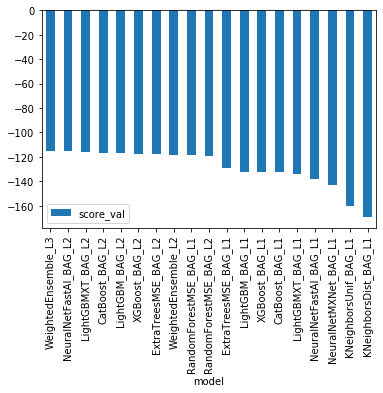

```python
# Output the model's `score_val` in a bar chart to compare performance
predictor.leaderboard(silent=True).plot(kind="bar", x="model", y="score_val")
```

### Create predictions from test dataset

```python
predictions = predictor.predict(test)
predictions.head()
```

```
0     97.214600
1     96.948883
2     96.950058
3    108.935791
4    108.872841
Name: count, dtype: float32
```

#### NOTE: Kaggle will reject the submission if we don't set everything to be > 0.

```python
# Describe the `predictions` series to see if there are any negative values
predictions.describe()
```

```
count    6493.000000
mean      211.698288
std       128.083145
min        -6.528394
25%       108.016884
50%       194.046051
75%       297.420441
max       658.842163
Name: count, dtype: float64
```

```python
# How many negative values do we have?
predictions.where(predictions < 0).count()
```

```
3
```

```python
# Set them to zero
Relu = lambda x : max(0, x)
predictions = predictions.apply(Relu)
```

```python
# Sanity check
predictions.where(predictions < 0).count()
```

```
0
```

### Set predictions to submission dataframe, save, and submit

```python
submission["count"] = predictions
submission.to_csv("submission.csv", index=False)
```

```python
!kaggle competitions submit -c bike-sharing-demand -f submission.csv -m "first raw submission"
```

```
Successfully submitted to Bike Sharing Demand
```

#### View submission via the command line or in the web browser under the competition's page - `My Submissions`

```python
!kaggle competitions submissions -c bike-sharing-demand | tail -n +1 | head -n 6
```

```
fileName                      date                 description                        status    publicScore  privateScore
----------------------------  -------------------  ---------------------------------  --------  -----------  ------------
submission.csv                2021-11-21 02:04:09  first raw submission               complete  1.39589      1.39589
submission_new_hpo.csv        2021-11-21 01:28:49  new features with hyperparameters  complete  1.24456      1.24456
submission_new_hpo.csv        2021-11-21 00:17:31  new features with hyperparameters  complete  1.28796      1.28796
submission_new_features2.csv  2021-11-20 19:42:09  new features 2                     complete  1.33479      1.33479
```

#### Initial score of 1.3958

## Step 4: Exploratory Data Analysis and Creating an additional feature

- Any additional feature will do, but a great suggestion would be to separate out the datetime into hour, day, or month parts.

```
array([[<matplotlib.axes._subplots.AxesSubplot object at 0x7f60005e3850>,
      dtype=object)
```

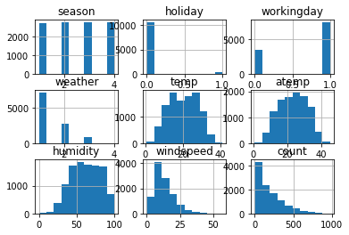

```python
# Create a histogram of all features to show the distribution of each one relative to the data. This is part of the exploritory data analysis
train.hist()
```

```python
train["datetime"] = pd.to_datetime(train["datetime"])
test["datetime"] = pd.to_datetime(test["datetime"])
```

Slight modification here. I do believe the best way to use the datetime parameter is to categorize month and weekday to catch individual patterns.

```python
# Split the date into year, month and day.
train["year"] = train.datetime.dt.year
train["month"] = train.datetime.dt.month
train["day"] = train.datetime.dt.day_name()
train["hour"] = train.datetime.dt.hour

test["year"] = test.datetime.dt.year
test["month"] = test.datetime.dt.month
test["day"] = test.datetime.dt.day_name()
test["hour"] = test.datetime.dt.hour

del train["datetime"]
del test["datetime"]
```

## Make category types for these so models know they are not just numbers

- AutoGluon originally sees these as ints, but in reality they are int representations of a category.
- Setting the dtype to category will classify these as categories in AutoGluon.

```python
train["season"] = train["season"].astype("category")
train["weather"] = train["weather"].astype("category")
train["month"] = train["month"].astype("category")
train["day"] = train["day"].astype("category")
train["hour"] = train["hour"].astype("category")

test["season"] = test["season"].astype("category")
test["weather"] = test["weather"].astype("category")
test["month"] = test["month"].astype("category")
test["day"] = test["day"].astype("category")
test["hour"] = test["hour"].astype("category")
```

```python
# I do think the year should also be categorized
train["year"] = train["year"].astype("category")
test["year"] = test["year"].astype("category")
```

```python
# View are new feature
train.head()
```

|  | season | holiday | workingday | weather | temp | atemp | humidity | windspeed | count | year | month | day | hour |
| --- | --- | --- | --- | --- | --- | --- | --- | --- | --- | --- | --- | --- | --- |
| 0 | 1 | 0 | 0 | 1 | 9.84 | 14.395 | 81 | 0.0 | 16 | 2011 | 1 | Saturday | 0 |
| 1 | 1 | 0 | 0 | 1 | 9.02 | 13.635 | 80 | 0.0 | 40 | 2011 | 1 | Saturday | 1 |
| 2 | 1 | 0 | 0 | 1 | 9.02 | 13.635 | 80 | 0.0 | 32 | 2011 | 1 | Saturday | 2 |
| 3 | 1 | 0 | 0 | 1 | 9.84 | 14.395 | 75 | 0.0 | 13 | 2011 | 1 | Saturday | 3 |
| 4 | 1 | 0 | 0 | 1 | 9.84 | 14.395 | 75 | 0.0 | 1 | 2011 | 1 | Saturday | 4 |

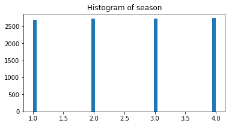

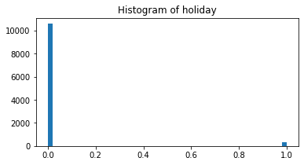

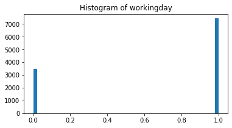

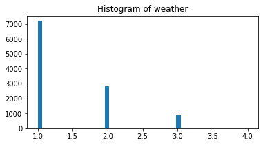

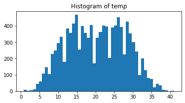

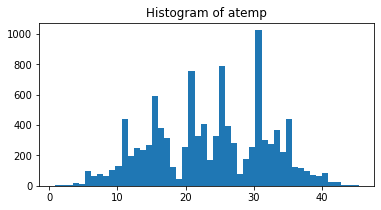

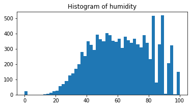

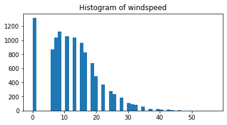

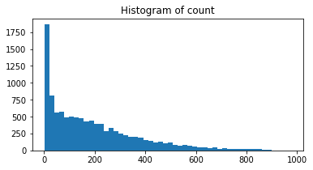

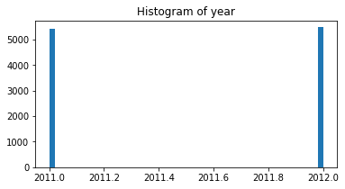

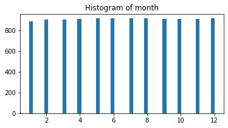

```
Using categorical units to plot a list of strings that are all parsable as floats or dates. If these strings should be plotted as numbers, cast to the appropriate data type before plotting.
Using categorical units to plot a list of strings that are all parsable as floats or dates. If these strings should be plotted as numbers, cast to the appropriate data type before plotting.
```

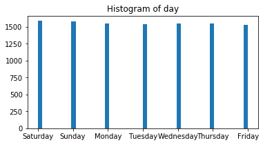

[1 more figures not shown]

```python
# View histogram of all features again now with the hour feature
# Another way to plot the hists, clearer
n_bins = 50 # can decrease to get a wider bin (or vice versa)

for column_name in train.columns:
    ax=plt.subplots(figsize=(6,3))
    # get data by column_name and display a histogram
    ax = plt.hist(train[column_name], bins=n_bins)
    title="Histogram of " + column_name
    plt.title(title, fontsize=12)
    plt.show()
```

As we can see, the following features should be normalized:  
temp  
atemp  
humidity  
windspeed

```python
scaler = StandardScaler()
scaler.fit(train[["temp", "atemp", "humidity", "windspeed"]]) # Let's train it on the train dataset
train[["temp", "atemp", "humidity", "windspeed"]] = scaler.transform(train[["temp", "atemp", "humidity", "windspeed"]])
test[["temp", "atemp", "humidity", "windspeed"]] = scaler.transform(test[["temp", "atemp", "humidity", "windspeed"]])
```

```python
# Sanity check
train.describe()
```

|  | holiday | workingday | temp | atemp | humidity | windspeed | count |
| --- | --- | --- | --- | --- | --- | --- | --- |
| count | 10886.000000 | 10886.000000 | 1.088600e+04 | 1.088600e+04 | 1.088600e+04 | 1.088600e+04 | 10886.000000 |
| mean | 0.028569 | 0.680875 | 1.036139e-14 | -3.990153e-15 | -1.667583e-15 | -6.407188e-16 | 191.574132 |
| std | 0.166599 | 0.466159 | 1.000046e+00 | 1.000046e+00 | 1.000046e+00 | 1.000046e+00 | 181.144454 |
| min | 0.000000 | 0.000000 | -2.491372e+00 | -2.701736e+00 | -3.215858e+00 | -1.567754e+00 | 1.000000 |
| 25% | 0.000000 | 0.000000 | -8.074281e-01 | -8.248654e-01 | -7.735577e-01 | -7.101642e-01 | 42.000000 |
| 50% | 0.000000 | 1.000000 | 3.454398e-02 | 6.902305e-02 | 5.899992e-03 | 2.432639e-02 | 145.000000 |
| 75% | 0.000000 | 1.000000 | 7.712696e-01 | 8.738177e-01 | 7.853577e-01 | 5.142603e-01 | 284.000000 |
| max | 1.000000 | 1.000000 | 2.665707e+00 | 2.572501e+00 | 1.980526e+00 | 5.413599e+00 | 977.000000 |

## Step 5: Rerun the model with the same settings as before, just with more features

```python
predictor_new_features = TabularPredictor(label="count", problem_type="regression", eval_metric="root_mean_squared_error")
```

```
No path specified. Models will be saved in: "AutogluonModels/ag-20211121_021708/"
```

```python
predictor_new_features.fit(
    train_data=train,
    time_limit=600,
    presets="best_quality"
)
```

```
Presets specified: ['best_quality']
Beginning AutoGluon training ... Time limit = 600s
AutoGluon will save models to "AutogluonModels/ag-20211121_021708/"
AutoGluon Version:  0.3.1
Train Data Rows:    10886
Train Data Columns: 12
Preprocessing data ...
Using Feature Generators to preprocess the data ...
Fitting AutoMLPipelineFeatureGenerator...
	Available Memory:                    1521.81 MB
	Train Data (Original)  Memory Usage: 0.59 MB (0.0% of available memory)
	Inferring data type of each feature based on column values. Set feature_metadata_in to manually specify special dtypes of the features.
	Stage 1 Generators:
		Fitting AsTypeFeatureGenerator...
			Note: Converting 3 features to boolean dtype as they only contain 2 unique values.
	Stage 2 Generators:
		Fitting FillNaFeatureGenerator...
	Stage 3 Generators:
		Fitting IdentityFeatureGenerator...
		Fitting CategoryFeatureGenerator...
			Fitting CategoryMemoryMinimizeFeatureGenerator...
	Stage 4 Generators:
		Fitting DropUniqueFeatureGenerator...
	Types of features in original data (raw dtype, special dtypes):
		('category', []) : 6 | ['season', 'weather', 'year', 'month', 'day', ...]
		('float', [])    : 4 | ['temp', 'atemp', 'humidity', 'windspeed']
		('int', [])      : 2 | ['holiday', 'workingday']
	Types of features in processed data (raw dtype, special dtypes):
		('category', [])  : 5 | ['season', 'weather', 'month', 'day', 'hour']
		('float', [])     : 4 | ['temp', 'atemp', 'humidity', 'windspeed']
		('int', ['bool']) : 3 | ['holiday', 'workingday', 'year']
	0.1s = Fit runtime
	12 features in original data used to generate 12 features in processed data.
	Train Data (Processed) Memory Usage: 0.44 MB (0.0% of available memory)
Data preprocessing and feature engineering runtime = 0.13s ...
AutoGluon will gauge predictive performance using evaluation metric: 'root_mean_squared_error'
	To change this, specify the eval_metric argument of fit()
AutoGluon will fit 2 stack levels (L1 to L2) ...
Fitting 11 L1 models ...
Fitting model: KNeighborsUnif_BAG_L1 ... Training model for up to 399.81s of the 599.87s of remaining time.
	-164.5397	 = Validation score   (root_mean_squared_error)
	0.03s	 = Training   runtime
	0.1s	 = Validation runtime
Fitting model: KNeighborsDist_BAG_L1 ... Training model for up to 399.44s of the 599.49s of remaining time.
	-178.9618	 = Validation score   (root_mean_squared_error)
	0.02s	 = Training   runtime
	0.1s	 = Validation runtime
Fitting model: LightGBMXT_BAG_L1 ... Training model for up to 399.08s of the 599.14s of remaining time.
```

```
[1000]	train_set's rmse: 23.2393	valid_set's rmse: 34.1377
```

```
[1000]	train_set's rmse: 23.4264	valid_set's rmse: 37.7752
[2000]	train_set's rmse: 18.4777	valid_set's rmse: 37.0387
```

```
[1000]	train_set's rmse: 23.6861	valid_set's rmse: 32.5028
```

```
[1000]	train_set's rmse: 23.5042	valid_set's rmse: 37.2534
```

```
[1000]	train_set's rmse: 23.4529	valid_set's rmse: 36.5101
[2000]	train_set's rmse: 18.3501	valid_set's rmse: 36.234
```

```
[1000]	train_set's rmse: 23.2685	valid_set's rmse: 38.9965
```

```
[1000]	train_set's rmse: 23.5759	valid_set's rmse: 34.767
[2000]	train_set's rmse: 18.529	valid_set's rmse: 34.1311
[3000]	train_set's rmse: 15.411	valid_set's rmse: 34.0192
```

```
[1000]	train_set's rmse: 23.0362	valid_set's rmse: 38.5492
```

```
[1000]	train_set's rmse: 23.4335	valid_set's rmse: 33.5699
```

```
	-35.7275	 = Validation score   (root_mean_squared_error)
	32.67s	 = Training   runtime
	1.94s	 = Validation runtime
Fitting model: LightGBM_BAG_L1 ... Training model for up to 360.35s of the 560.41s of remaining time.
```

```
[1000]	train_set's rmse: 18.0684	valid_set's rmse: 36.0523
```

```
[1000]	train_set's rmse: 18.0096	valid_set's rmse: 37.9037
```

```
[1000]	train_set's rmse: 18.378	valid_set's rmse: 33.2587
```

```
[1000]	train_set's rmse: 17.9537	valid_set's rmse: 37.9976
```

```
[1000]	train_set's rmse: 17.8744	valid_set's rmse: 38.3281
```

```
[1000]	train_set's rmse: 17.9514	valid_set's rmse: 40.4487
```

```
[1000]	train_set's rmse: 18.3437	valid_set's rmse: 35.2355
```

```
[1000]	train_set's rmse: 17.7143	valid_set's rmse: 40.9344
```

```
[1000]	train_set's rmse: 17.9413	valid_set's rmse: 34.9656
```

```
	-37.1298	 = Validation score   (root_mean_squared_error)
	20.99s	 = Training   runtime
	0.99s	 = Validation runtime
Fitting model: RandomForestMSE_BAG_L1 ... Training model for up to 335.72s of the 535.77s of remaining time.
	-40.3307	 = Validation score   (root_mean_squared_error)
	7.51s	 = Training   runtime
	0.4s	 = Validation runtime
Fitting model: CatBoost_BAG_L1 ... Training model for up to 325.69s of the 525.75s of remaining time.
	Time limit exceeded... Skipping CatBoost_BAG_L1.
Fitting model: ExtraTreesMSE_BAG_L1 ... Training model for up to 268.65s of the 468.71s of remaining time.
	-39.5972	 = Validation score   (root_mean_squared_error)
	3.61s	 = Training   runtime
	0.4s	 = Validation runtime
Fitting model: NeuralNetFastAI_BAG_L1 ... Training model for up to 262.41s of the 462.47s of remaining time.
	-35.345	 = Validation score   (root_mean_squared_error)
	154.9s	 = Training   runtime
	0.39s	 = Validation runtime
Fitting model: XGBoost_BAG_L1 ... Training model for up to 106.3s of the 306.36s of remaining time.
	-41.8566	 = Validation score   (root_mean_squared_error)
	35.19s	 = Training   runtime
	0.36s	 = Validation runtime
Fitting model: NeuralNetMXNet_BAG_L1 ... Training model for up to 67.27s of the 267.33s of remaining time.
	Ran out of time, stopping training early. (Stopping on epoch 2)
	Ran out of time, stopping training early. (Stopping on epoch 2)
	Ran out of time, stopping training early. (Stopping on epoch 3)
	Ran out of time, stopping training early. (Stopping on epoch 3)
	Ran out of time, stopping training early. (Stopping on epoch 3)
	Ran out of time, stopping training early. (Stopping on epoch 4)
	Ran out of time, stopping training early. (Stopping on epoch 3)
	Ran out of time, stopping training early. (Stopping on epoch 4)
	Ran out of time, stopping training early. (Stopping on epoch 4)
	Ran out of time, stopping training early. (Stopping on epoch 5)
	-175.6252	 = Validation score   (root_mean_squared_error)
	61.11s	 = Training   runtime
	2.38s	 = Validation runtime
Fitting model: LightGBMLarge_BAG_L1 ... Training model for up to 3.22s of the 203.27s of remaining time.
	Ran out of time, early stopping on iteration 18. Best iteration is:
	[18]	train_set's rmse: 115.648	valid_set's rmse: 115.689
	Time limit exceeded... Skipping LightGBMLarge_BAG_L1.
Completed 1/20 k-fold bagging repeats ...
```

[output cut: 41 more lines]

```
Fitting model: NeuralNetMXNet_BAG_L2 ... Training model for up to 3.08s of the 3.05s of remaining time.
	Time limit exceeded... Skipping NeuralNetMXNet_BAG_L2.
Fitting model: LightGBMLarge_BAG_L2 ... Training model for up to 2.44s of the 2.41s of remaining time.
	Ran out of time, early stopping on iteration 1. Best iteration is:
	[1]	train_set's rmse: 176.192	valid_set's rmse: 172.84
	Ran out of time, early stopping on iteration 2. Best iteration is:
	[2]	train_set's rmse: 169.999	valid_set's rmse: 177.435
	Time limit exceeded... Skipping LightGBMLarge_BAG_L2.
Completed 1/20 k-fold bagging repeats ...
Fitting model: WeightedEnsemble_L3 ... Training model for up to 360.0s of the 1.81s of remaining time.
	-34.474	 = Validation score   (root_mean_squared_error)
	0.23s	 = Training   runtime
	0.0s	 = Validation runtime
AutoGluon training complete, total runtime = 598.66s ...
TabularPredictor saved. To load, use: predictor = TabularPredictor.load("AutogluonModels/ag-20211121_021708/")
```

```
<autogluon.tabular.predictor.predictor.TabularPredictor at 0x7f60245da350>
```

```python
predictor_new_features.fit_summary()
```

```
*** Summary of fit() ***
Estimated performance of each model:
                     model   score_val  pred_time_val    fit_time  pred_time_val_marginal  fit_time_marginal  stack_level  can_infer  fit_order
0      WeightedEnsemble_L2  -34.316606       4.121860  220.019732                0.000577           0.340120            2       True         10
1      WeightedEnsemble_L3  -34.473998       8.634341  496.191876                0.000542           0.232417            3       True         17
2     ExtraTreesMSE_BAG_L2  -34.864363       7.523641  322.748903                0.460837           6.718493            2       True         15
3          CatBoost_BAG_L2  -34.888463       7.149204  359.622627                0.086400          43.592216            2       True         14
4          LightGBM_BAG_L2  -34.976713       7.198732  324.631497                0.135928           8.601086            2       True         12
5   RandomForestMSE_BAG_L2  -35.322165       7.528275  342.290699                0.465472          26.260288            2       True         13
6   NeuralNetFastAI_BAG_L1  -35.344984       0.390632  154.902950                0.390632         154.902950            1       True          7
7   NeuralNetFastAI_BAG_L2  -35.718791       7.485163  410.787376                0.422359          94.756966            2       True         16
8        LightGBMXT_BAG_L1  -35.727531       1.944712   32.665301                1.944712          32.665301            1       True          3
9        LightGBMXT_BAG_L2  -35.898507       7.332540  326.564067                0.269736          10.533656            2       True         11
10         LightGBM_BAG_L1  -37.129807       0.987460   20.992198                0.987460          20.992198            1       True          4
11    ExtraTreesMSE_BAG_L1  -39.597210       0.395953    3.606146                0.395953           3.606146            1       True          6
12  RandomForestMSE_BAG_L1  -40.330714       0.402527    7.513019                0.402527           7.513019            1       True          5
13          XGBoost_BAG_L1  -41.856571       0.355947   35.192866                0.355947          35.192866            1       True          8
14   KNeighborsUnif_BAG_L1 -164.539695       0.103666    0.026569                0.103666           0.026569            1       True          1
15   NeuralNetMXNet_BAG_L1 -175.625249       2.377673   61.114346                2.377673          61.114346            1       True          9
16   KNeighborsDist_BAG_L1 -178.961800       0.104234    0.017017                0.104234           0.017017            1       True          2
Number of models trained: 17
Types of models trained:
{'StackerEnsembleModel_LGB', 'StackerEnsembleModel_XT', 'WeightedEnsembleModel', 'StackerEnsembleModel_RF', 'StackerEnsembleModel_CatBoost', 'StackerEnsembleModel_NNFastAiTabular', 'StackerEnsembleModel_XGBoost', 'StackerEnsembleModel_TabularNeuralNet', 'StackerEnsembleModel_KNN'}
Bagging used: True  (with 10 folds)
Multi-layer stack-ensembling used: True  (with 3 levels)
Feature Metadata (Processed):
(raw dtype, special dtypes):
('category', [])  : 5 | ['season', 'weather', 'month', 'day', 'hour']
('float', [])     : 4 | ['temp', 'atemp', 'humidity', 'windspeed']
('int', ['bool']) : 3 | ['holiday', 'workingday', 'year']
Plot summary of models saved to file: AutogluonModels/ag-20211121_021708/SummaryOfModels.html
*** End of fit() summary ***
```

[output not shown]

[output cut: 163 more lines]

```
 2          15
 3          14
 4          12
 5          13
 6           7
 7          16
 8           3
 9          11
 10          4
 11          6
 12          5
 13          8
 14          1
 15          9
 16          2  }
```

[figure not shown]

```python
# Output the model's `score_val` in a bar chart to compare performance
predictor_new_features.leaderboard(silent=True).plot(kind="bar", x="model", y="score_val")
```

```python
# Remember to set all negative values to zero
predictions = predictor_new_features.predict(test)

Relu = lambda x : max(0, x)
predictions = predictions.apply(Relu)
```

```python
# Same submitting predictions
submission_new_features = submission
submission_new_features["count"] = predictions
submission_new_features.to_csv("submission_new_features2.csv", index=False)
```

```python
!kaggle competitions submit -c bike-sharing-demand -f submission_new_features2.csv -m "new features 2"
```

```
Successfully submitted to Bike Sharing Demand
```

```python
!kaggle competitions submissions -c bike-sharing-demand | tail -n +1 | head -n 6
```

```
fileName                      date                 description                        status    publicScore  privateScore
----------------------------  -------------------  ---------------------------------  --------  -----------  ------------
submission_new_features2.csv  2021-11-21 02:34:10  new features 2                     complete  0.46080      0.46080
submission.csv                2021-11-21 02:04:09  first raw submission               complete  1.39589      1.39589
submission_new_hpo.csv        2021-11-21 01:28:49  new features with hyperparameters  complete  1.24456      1.24456
submission_new_hpo.csv        2021-11-21 00:17:31  new features with hyperparameters  complete  1.28796      1.28796
```

#### New Score of 0.46080

## Outside the project

Let's inspect the hyperparameters of some of our best models.  
Quick tip: When you can't find the documentation of a specific object, you can have a look to all its attributes like this: "Object._ *dict* _.keys()"

It seems like this model contains all the others. I don't think they are stacked tho, as there is the "L_1"prefix.

```python
file_name = "AutogluonModels/ag-20211120_192752/models/XGBoost_BAG_L1/model.pkl"
XGB_loaded_model = pickle.load(open(file_name, "rb"))
```

```python
print(XGB_loaded_model.models)
```

```
['S1F1', 'S1F2', 'S1F3', 'S1F4', 'S1F5', 'S1F6', 'S1F7', 'S1F8', 'S1F9', 'S1F10']
```

```python
XGB_loaded_model.__dict__.keys()
```

```
dict_keys(['model_base', '_child_type', 'models', '_oof_pred_proba', '_oof_pred_model_repeats', '_n_repeats', '_n_repeats_finished', '_k_fold_end', '_k', '_k_per_n_repeat', '_random_state', 'low_memory', '_bagged_mode', '_child_oof', '_cv_splitters', 'name', 'path_root', 'path', 'num_classes', 'mode…
```

Let's inspect a specific model

```python
file_name = "AutogluonModels/ag-20211120_192752/models/XGBoost_BAG_L1/S1F10/model.pkl"
XGB_loaded_model = pickle.load(open(file_name, "rb"))
```

```python
print(XGB_loaded_model.model)
```

```
XGBRegressor(base_score=0.5, booster='gbtree', colsample_bylevel=1,
             colsample_bynode=1, colsample_bytree=1, gamma=0, gpu_id=-1,
             importance_type='gain', interaction_constraints='',
             learning_rate=0.1, max_delta_step=0, max_depth=6,
             min_child_weight=1, missing=nan, monotone_constraints='()',
             n_estimators=10000, n_jobs=-1, num_parallel_tree=1, random_state=0,
             reg_alpha=0, reg_lambda=1, scale_pos_weight=1, subsample=1,
             tree_method='hist', validate_parameters=1, verbosity=None)
```

## Step 6: Hyper parameter optimization

- There are many options for hyper parameter optimization.
- Options are to change the AutoGluon higher level parameters or the individual model hyperparameters.
- The hyperparameters of the models themselves that are in AutoGluon. Those need the hyperparameter and hyperparameter_tune_kwargs arguments

Helpfull documentation @

- https://auto.gluon.ai/stable/api/autogluon.predictor.html?highlight=gbm#module-0

```python
nn_options = {
    'epochs': 20,  # number of training epochs (controls training time of NN models)
    'lr': ag.space.Real(1e-4, 1e-2, default=5e-4, log=True),  # learning rate used in training (real-valued hyperparameter searched on log-scale)
    'layers': ag.space.Categorical([64, 64, 32, 16, 1], [64, 32, 16, 1], [32, 16, 1]),  # each choice for categorical hyperparameter 'layers' corresponds to list of sizes for each NN layer to use
    'dropout_prob': ag.space.Real(0.0, 0.5, default=0.1),  # dropout probability (real-valued hyperparameter)
}

gbm_options = {  # specifies non-default hyperparameter values for lightGBM
    'num_iterations': ag.space.Real(100, 200, default=150),  # number of boosting rounds (controls training time of GBM models)
    'num_leaves': ag.space.Int(lower=26, upper=66, default=36),  # number of leaves in trees (integer hyperparameter)
}

xgb_options = {  # specifies non-default hyperparameter values for XGB
    'eta' : ag.space.Real(0, 1, default=0.3),
    'gamma' : ag.space.Real(0, 1, default=0),
    'max_depth' : ag.space.Int(5, 15, default=6),
    'min_child_weight' : ag.space.Int(0, 5, default=1)
}

hyperparameters = {  # hyperparameters of each model type
                   'NN': nn_options,
                   'GBM': gbm_options,
                   'XGB': xgb_options
                  }  # When these keys are missing from hyperparameters dict, no models of that type are trained


hyperparameter_tune_kwargs = {    # HPO is not performed unless hyperparameter_tune_kwargs is specified
    'num_trials': 20,             # try at most 20 different hyperparameter configurations for each type of model
    'scheduler' : 'local',
    'searcher': 'auto'            # to tune hyperparameters using Bayesian optimization routine with a local scheduler
}


predictor_new_hpo = TabularPredictor(label="count", problem_type="regression", eval_metric="root_mean_squared_error")

predictor_new_hpo.fit(
    train_data=train,
    time_limit=1200, # 20 minutes
    presets="best_quality",
    hyperparameters=hyperparameters,
    hyperparameter_tune_kwargs=hyperparameter_tune_kwargs,
    num_bag_folds=5,
    num_stack_levels=2,
)
```

```
No path specified. Models will be saved in: "AutogluonModels/ag-20211121_023512/"
Presets specified: ['best_quality']
Warning: hyperparameter tuning is currently experimental and may cause the process to hang.
Beginning AutoGluon training ... Time limit = 1200s
AutoGluon will save models to "AutogluonModels/ag-20211121_023512/"
AutoGluon Version:  0.3.1
Train Data Rows:    10886
Train Data Columns: 12
Preprocessing data ...
Using Feature Generators to preprocess the data ...
Fitting AutoMLPipelineFeatureGenerator...
	Available Memory:                    1270.53 MB
	Train Data (Original)  Memory Usage: 0.59 MB (0.0% of available memory)
	Inferring data type of each feature based on column values. Set feature_metadata_in to manually specify special dtypes of the features.
	Stage 1 Generators:
		Fitting AsTypeFeatureGenerator...
			Note: Converting 3 features to boolean dtype as they only contain 2 unique values.
	Stage 2 Generators:
		Fitting FillNaFeatureGenerator...
	Stage 3 Generators:
		Fitting IdentityFeatureGenerator...
		Fitting CategoryFeatureGenerator...
			Fitting CategoryMemoryMinimizeFeatureGenerator...
	Stage 4 Generators:
		Fitting DropUniqueFeatureGenerator...
	Types of features in original data (raw dtype, special dtypes):
		('category', []) : 6 | ['season', 'weather', 'year', 'month', 'day', ...]
		('float', [])    : 4 | ['temp', 'atemp', 'humidity', 'windspeed']
		('int', [])      : 2 | ['holiday', 'workingday']
	Types of features in processed data (raw dtype, special dtypes):
		('category', [])  : 5 | ['season', 'weather', 'month', 'day', 'hour']
		('float', [])     : 4 | ['temp', 'atemp', 'humidity', 'windspeed']
		('int', ['bool']) : 3 | ['holiday', 'workingday', 'year']
	0.1s = Fit runtime
	12 features in original data used to generate 12 features in processed data.
	Train Data (Processed) Memory Usage: 0.44 MB (0.0% of available memory)
Data preprocessing and feature engineering runtime = 0.16s ...
AutoGluon will gauge predictive performance using evaluation metric: 'root_mean_squared_error'
	To change this, specify the eval_metric argument of fit()
AutoGluon will fit 3 stack levels (L1 to L3) ...
Fitting 3 L1 models ...
Hyperparameter tuning model: LightGBM_BAG_L1 ...
```

[output not shown]

[output cut: 446 more lines]

[output not shown]

```
	Time limit exceeded
Fitted model: XGBoost_BAG_L1/T0 ...
	-43.2152	 = Validation score   (root_mean_squared_error)
	3.48s	 = Training   runtime
	0.06s	 = Validation runtime
Fitted model: XGBoost_BAG_L1/T1 ...
	-40.4866	 = Validation score   (root_mean_squared_error)
	13.23s	 = Training   runtime
	0.16s	 = Validation runtime
Hyperparameter tuning model: NeuralNetMXNet_BAG_L1 ...
```

[output not shown]

[output cut: 62 more lines]

```
	Ran out of time, stopping training early. (Stopping on epoch 97)
Attempting to fit model without HPO, but search space is provided. fit() will only consider default hyperparameter values from search space.
	Ran out of time, stopping training early. (Stopping on epoch 94)
Attempting to fit model without HPO, but search space is provided. fit() will only consider default hyperparameter values from search space.
	Ran out of time, stopping training early. (Stopping on epoch 114)
	-68.1664	 = Validation score   (root_mean_squared_error)
	468.31s	 = Training   runtime
	1.41s	 = Validation runtime
Completed 1/20 k-fold bagging repeats ...
Fitting model: WeightedEnsemble_L2 ... Training model for up to 360.0s of the 699.91s of remaining time.
	-68.1664	 = Validation score   (root_mean_squared_error)
	0.0s	 = Training   runtime
	0.0s	 = Validation runtime
Fitting 3 L2 models ...
Hyperparameter tuning model: LightGBM_BAG_L2 ...
```

[output not shown]

[output cut: 446 more lines]

[output not shown]

```
	Time limit exceeded
Fitted model: XGBoost_BAG_L2/T0 ...
	-48.5231	 = Validation score   (root_mean_squared_error)
	4.9s	 = Training   runtime
	0.08s	 = Validation runtime
Fitted model: XGBoost_BAG_L2/T1 ...
	-48.3235	 = Validation score   (root_mean_squared_error)
	6.47s	 = Training   runtime
	0.06s	 = Validation runtime
Fitted model: XGBoost_BAG_L2/T2 ...
	-50.6522	 = Validation score   (root_mean_squared_error)
	10.97s	 = Training   runtime
	0.14s	 = Validation runtime
Hyperparameter tuning model: NeuralNetMXNet_BAG_L2 ...
```

[output not shown]

[output cut: 108 more lines]

```
	Ran out of time, stopping training early. (Stopping on epoch 73)
Attempting to fit model without HPO, but search space is provided. fit() will only consider default hyperparameter values from search space.
	Ran out of time, stopping training early. (Stopping on epoch 80)
Attempting to fit model without HPO, but search space is provided. fit() will only consider default hyperparameter values from search space.
	Ran out of time, stopping training early. (Stopping on epoch 111)
	-57.6342	 = Validation score   (root_mean_squared_error)
	400.58s	 = Training   runtime
	1.42s	 = Validation runtime
Completed 1/20 k-fold bagging repeats ...
Fitting model: WeightedEnsemble_L3 ... Training model for up to 360.0s of the 262.32s of remaining time.
	-57.6342	 = Validation score   (root_mean_squared_error)
	0.0s	 = Training   runtime
	0.0s	 = Validation runtime
Fitting 3 L3 models ...
Hyperparameter tuning model: LightGBM_BAG_L3 ...
```

[output not shown]

[output cut: 446 more lines]

[output not shown]

```
	Time limit exceeded
Fitted model: XGBoost_BAG_L3/T0 ...
	-45.8375	 = Validation score   (root_mean_squared_error)
	6.19s	 = Training   runtime
	0.1s	 = Validation runtime
Hyperparameter tuning model: NeuralNetMXNet_BAG_L3 ...
```

[output not shown]

[output cut: 16 more lines]

```
	Ran out of time, stopping training early. (Stopping on epoch 41)
Attempting to fit model without HPO, but search space is provided. fit() will only consider default hyperparameter values from search space.
	Ran out of time, stopping training early. (Stopping on epoch 46)
Attempting to fit model without HPO, but search space is provided. fit() will only consider default hyperparameter values from search space.
	Ran out of time, stopping training early. (Stopping on epoch 55)
	-104.1347	 = Validation score   (root_mean_squared_error)
	230.8s	 = Training   runtime
	1.43s	 = Validation runtime
Completed 1/20 k-fold bagging repeats ...
Fitting model: WeightedEnsemble_L4 ... Training model for up to 360.0s of the 16.45s of remaining time.
	-104.1347	 = Validation score   (root_mean_squared_error)
	0.0s	 = Training   runtime
	0.0s	 = Validation runtime
AutoGluon training complete, total runtime = 1183.79s ...
TabularPredictor saved. To load, use: predictor = TabularPredictor.load("AutogluonModels/ag-20211121_023512/")
```

```
<autogluon.tabular.predictor.predictor.TabularPredictor at 0x7f6024de18d0>
```